# R Notebook : For Hyper parameter optimization

## Hyper parameter optimization

# Libraries

```r
install.packages("pdp")
```

```
Error in install.packages : Updating loaded packages
```

# Feature spaces : FS1

For SOM Brero model input feature space FS1 was extracted from the original charite.rda. After NA removal and splitting the Before and after treatment data two dataframes were created. FS1_data_T0 and FS1_data_T1

```r
head(FS1_data_T0)
```

| .age | tq_em | tq_co | tq_pb | tq_inti | tq_aku | tq_sl | tq_som | tq_tf | sozk_soz01_male | sozk_soz05_partner | sozk_soz10_keinAbschl | sozk_soz11_job | sozk_soz1617_arblos | sozk_soz1920_krank | sozk_soz21_tindauer | sozk_soz2224_psycho | tinskal_beein10 | tinskal_laut10 | tinskal_haeuf10 | psq_sorgen | psq_anspan | psq_freude | psq_anford | psq_psq_sum | sf8_gh_sf36ag | sf8_pf_sf36kf | sf8_rp_sf36kr | sf8_bp_sf36ks | sf8_vt_sf36vit | … |
| --- | --- | --- | --- | --- | --- | --- | --- | --- | --- | --- | --- | --- | --- | --- | --- | --- | --- | --- | --- | --- | --- | --- | --- | --- | --- | --- | --- | --- | --- | --- |
| 76 | 20 | 12 | 32 | 13 | 8 | 4 | 4 | 61 | 1 | 1 | 0 | 0 | 0 | 0.0 | 5.00 | 12.0 | 8.40 | 4.71 | 9.71 | 0.73 | 0.67 | 0.60 | 0.60 | 0.63 | 32.56 | 48.33 | 38.71 | 47.67 | 35.81 | … |
| 59 | 24 | 14 | 38 | 16 | 14 | 8 | 6 | 82 | 1 | 0 | 0 | 0 | 0 | 0.0 | 5.00 | 12.0 | 8.93 | 8.74 | 10.00 | 0.73 | 0.47 | 0.60 | 1.00 | 0.70 | 22.81 | 21.46 | 46.92 | 25.45 | 35.81 | … |
| 48 | 1 | 2 | 3 | 6 | 3 | 3 | 0 | 15 | 0 | 1 | 0 | 1 | 0 | 0.0 | 5.00 | 0.0 | 0.20 | 0.10 | 0.10 | 0.33 | 0.53 | 0.67 | 0.73 | 0.44 | 38.41 | 40.07 | 53.98 | 40.07 | 55.62 | … |
| 54 | 1 | 2 | 3 | 10 | 6 | 2 | 0 | 21 | 1 | 1 | 0 | 1 | 0 | 3.5 | 5.00 | 12.0 | 6.12 | 6.99 | 6.07 | 0.27 | 0.33 | 0.60 | 0.53 | 0.34 | 46.43 | 48.33 | 53.98 | 53.35 | 55.62 | … |
| 44 | 4 | 2 | 6 | 4 | 7 | 1 | 0 | 18 | 1 | 0 | 0 | 1 | 0 | 1.0 | 5.00 | 0.0 | 5.05 | 7.09 | 10.00 | 0.13 | 0.33 | 0.93 | 0.27 | 0.18 | 52.83 | 54.05 | 53.98 | 60.77 | 55.62 | … |
| 55 | 5 | 3 | 8 | 6 | 7 | 4 | 1 | 26 | 1 | 1 | 0 | 1 | 0 | 3.5 | 0.25 | 0.5 | 5.05 | 5.63 | 7.91 | 0.27 | 0.40 | 0.60 | 0.67 | 0.40 | 38.41 | 48.33 | 46.92 | 40.07 | 45.16 | … |

```r
#summary(FS1_data_T0)
dim(FS1_data_T0)
```

```
[1] 1743   44
```

```r
head(FS1_data_T1)
```

| .age | tq_em | tq_co | tq_pb | tq_inti | tq_aku | tq_sl | tq_som | tq_tf | sozk_soz01_male | sozk_soz05_partner | sozk_soz10_keinAbschl | sozk_soz11_job | sozk_soz1617_arblos | sozk_soz1920_krank | sozk_soz21_tindauer | sozk_soz2224_psycho | tinskal_beein10 | tinskal_laut10 | tinskal_haeuf10 | psq_sorgen | psq_anspan | psq_freude | psq_anford | psq_psq_sum | sf8_gh_sf36ag | sf8_pf_sf36kf | sf8_rp_sf36kr | sf8_bp_sf36ks | sf8_vt_sf36vit | … |
| --- | --- | --- | --- | --- | --- | --- | --- | --- | --- | --- | --- | --- | --- | --- | --- | --- | --- | --- | --- | --- | --- | --- | --- | --- | --- | --- | --- | --- | --- | --- |
| 76 | 21 | 14 | 35 | 13 | 9 | 6 | 5 | 68 | 1 | 0 | 0 | 1 | 0 | 3.5 | 5 | 12.0 | 7.77 | 7.96 | 10.00 | 0.73 | 0.60 | 0.13 | 0.60 | 0.72 | 38.41 | 30.31 | 28.32 | 40.07 | 35.81 | … |
| 59 | 23 | 10 | 33 | 15 | 10 | 8 | 6 | 72 | 0 | 1 | 1 | 0 | 0 | 0.0 | 5 | 5.5 | 9.37 | 9.85 | 9.81 | 0.87 | 0.60 | 0.40 | 0.93 | 0.78 | 22.81 | 30.31 | 28.32 | 25.45 | 35.81 | … |
| 48 | 1 | 1 | 2 | 9 | 3 | 2 | 1 | 17 | 0 | 1 | 0 | 1 | 0 | 0.0 | 5 | 0.0 | 7.33 | 8.93 | 9.42 | 0.40 | 0.40 | 0.60 | 0.60 | 0.43 | 46.43 | 40.07 | 53.98 | 31.48 | 55.62 | … |
| 54 | 15 | 6 | 21 | 13 | 10 | 5 | 2 | 51 | 1 | 1 | 0 | 0 | 0 | 3.5 | 5 | 0.0 | 8.01 | 7.33 | 10.00 | 0.60 | 0.67 | 0.33 | 0.33 | 0.52 | 38.41 | 54.05 | 46.92 | 31.48 | 45.16 | … |
| 44 | 4 | 4 | 8 | 5 | 5 | 2 | 0 | 20 | 1 | 0 | 0 | 1 | 0 | 1.0 | 5 | 0.0 | 2.09 | 3.01 | 10.00 | 0.13 | 0.33 | 0.93 | 0.33 | 0.22 | 46.43 | 48.33 | 46.92 | 60.77 | 55.62 | … |
| 55 | 3 | 3 | 6 | 3 | 4 | 1 | 0 | 14 | 1 | 1 | 0 | 1 | 0 | 3.5 | 5 | 0.0 | 4.08 | 2.77 | 9.85 | 0.27 | 0.40 | 0.67 | 0.53 | 0.37 | 38.41 | 40.07 | 53.98 | 47.67 | 45.16 | … |

```r
#summary(FS1_data_T1)
dim(FS1_data_T1)
```

```
[1] 1743   44
```

# Feature spaces : FS2

For SOM Brero model input feature space FS2 was extracted from the original charite.rda. After NA removal and splitting the Before and after treatment data two dataframes were created. FS2_data_T0 and FS2_data_T1

```r
head(FS2_data_T0)
```

| .age | tq_em | tq_co | tq_pb | tq_inti | tq_aku | tq_sl | tq_som | tq_tf | sozk_soz01_male | sozk_soz05_partner | sozk_soz10_keinAbschl | sozk_soz11_job | sozk_soz1617_arblos | sozk_soz1920_krank | sozk_soz21_tindauer | sozk_soz2224_psycho | tinskal_beein10 | tinskal_laut10 | tinskal_haeuf10 | acsa_acsa | psq_sorgen | psq_anspan | psq_freude | psq_anford | psq_psq_sum | sf8_gh_sf36ag | sf8_pf_sf36kf | sf8_rp_sf36kr | sf8_bp_sf36ks | … |
| --- | --- | --- | --- | --- | --- | --- | --- | --- | --- | --- | --- | --- | --- | --- | --- | --- | --- | --- | --- | --- | --- | --- | --- | --- | --- | --- | --- | --- | --- | --- |
| 76 | 20 | 12 | 32 | 13 | 8 | 4 | 4 | 61 | 1 | 1 | 0 | 0 | 0 | 0.0 | 5.00 | 12.0 | 8.40 | 4.71 | 9.71 | 5.8 | 0.73 | 0.67 | 0.60 | 0.60 | 0.63 | 32.56 | 48.33 | 38.71 | 47.67 | … |
| 59 | 24 | 14 | 38 | 16 | 14 | 8 | 6 | 82 | 1 | 0 | 0 | 0 | 0 | 0.0 | 5.00 | 12.0 | 8.93 | 8.74 | 10.00 | 0.3 | 0.73 | 0.47 | 0.60 | 1.00 | 0.70 | 22.81 | 21.46 | 46.92 | 25.45 | … |
| 48 | 1 | 2 | 3 | 6 | 3 | 3 | 0 | 15 | 0 | 1 | 0 | 1 | 0 | 0.0 | 5.00 | 0.0 | 0.20 | 0.10 | 0.10 | 8.1 | 0.33 | 0.53 | 0.67 | 0.73 | 0.44 | 38.41 | 40.07 | 53.98 | 40.07 | … |
| 54 | 1 | 2 | 3 | 10 | 6 | 2 | 0 | 21 | 1 | 1 | 0 | 1 | 0 | 3.5 | 5.00 | 12.0 | 6.12 | 6.99 | 6.07 | 8.5 | 0.27 | 0.33 | 0.60 | 0.53 | 0.34 | 46.43 | 48.33 | 53.98 | 53.35 | … |
| 44 | 4 | 2 | 6 | 4 | 7 | 1 | 0 | 18 | 1 | 0 | 0 | 1 | 0 | 1.0 | 5.00 | 0.0 | 5.05 | 7.09 | 10.00 | 5.1 | 0.13 | 0.33 | 0.93 | 0.27 | 0.18 | 52.83 | 54.05 | 53.98 | 60.77 | … |
| 55 | 5 | 3 | 8 | 6 | 7 | 4 | 1 | 26 | 1 | 1 | 0 | 1 | 0 | 3.5 | 0.25 | 0.5 | 5.05 | 5.63 | 7.91 | 5.6 | 0.27 | 0.40 | 0.60 | 0.67 | 0.40 | 38.41 | 48.33 | 46.92 | 40.07 | … |

```r
#summary(FS2_data_T0)
dim(FS2_data_T0)
```

```
[1] 1743   59
```

```r
head(FS2_data_T1)
```

| .age | tq_em | tq_co | tq_pb | tq_inti | tq_aku | tq_sl | tq_som | tq_tf | sozk_soz01_male | sozk_soz05_partner | sozk_soz10_keinAbschl | sozk_soz11_job | sozk_soz1617_arblos | sozk_soz1920_krank | sozk_soz21_tindauer | sozk_soz2224_psycho | tinskal_beein10 | tinskal_laut10 | tinskal_haeuf10 | acsa_acsa | psq_sorgen | psq_anspan | psq_freude | psq_anford | psq_psq_sum | sf8_gh_sf36ag | sf8_pf_sf36kf | sf8_rp_sf36kr | sf8_bp_sf36ks | … |
| --- | --- | --- | --- | --- | --- | --- | --- | --- | --- | --- | --- | --- | --- | --- | --- | --- | --- | --- | --- | --- | --- | --- | --- | --- | --- | --- | --- | --- | --- | --- |
| 76 | 21 | 14 | 35 | 13 | 9 | 6 | 5 | 68 | 0 | 1 | 0 | 0 | 0 | 0.0 | 5 | 12.0 | 7.77 | 7.96 | 10.00 | 7.3 | 0.73 | 0.60 | 0.13 | 0.60 | 0.72 | 38.41 | 30.31 | 28.32 | 40.07 | … |
| 59 | 23 | 10 | 33 | 15 | 10 | 8 | 6 | 72 | 0 | 1 | 1 | 0 | 0 | 0.0 | 5 | 5.5 | 9.37 | 9.85 | 9.81 | 9.8 | 0.87 | 0.60 | 0.40 | 0.93 | 0.78 | 22.81 | 30.31 | 28.32 | 25.45 | … |
| 48 | 1 | 1 | 2 | 9 | 3 | 2 | 1 | 17 | 0 | 1 | 0 | 1 | 0 | 0.0 | 5 | 0.0 | 7.33 | 8.93 | 9.42 | 6.6 | 0.40 | 0.40 | 0.60 | 0.60 | 0.43 | 46.43 | 40.07 | 53.98 | 31.48 | … |
| 54 | 15 | 6 | 21 | 13 | 10 | 5 | 2 | 51 | 1 | 1 | 0 | 0 | 0 | 3.5 | 5 | 0.0 | 8.01 | 7.33 | 10.00 | 3.1 | 0.60 | 0.67 | 0.33 | 0.33 | 0.52 | 38.41 | 54.05 | 46.92 | 31.48 | … |
| 44 | 4 | 4 | 8 | 5 | 5 | 2 | 0 | 20 | 1 | 0 | 0 | 1 | 0 | 1.0 | 5 | 0.0 | 2.09 | 3.01 | 10.00 | 7.6 | 0.13 | 0.33 | 0.93 | 0.33 | 0.22 | 46.43 | 48.33 | 46.92 | 60.77 | … |
| 55 | 3 | 3 | 6 | 3 | 4 | 1 | 0 | 14 | 1 | 1 | 0 | 1 | 0 | 3.5 | 5 | 0.0 | 4.08 | 2.77 | 9.85 | 5.0 | 0.27 | 0.40 | 0.67 | 0.53 | 0.37 | 38.41 | 40.07 | 53.98 | 47.67 | … |

```r
#summary(FS2_data_T1)
dim(FS2_data_T1)
```

```
[1] 1743   59
```

# Need for scaling

To standardize the ranges of the features. Scaling is important because distance between the data points is crutial .

```r
scaled_FS1_data_T0 <- scale(FS1_data_T0)
```

# Hyper Parameter combinations

Different hyper parameters of SOM Brero model were considered with respect to FS1 and FS2 data.

# Map Size :

- Larger map sizes result in more detailed patterns; smaller map sizes result in more general patterns

Two radius types are allowed in SOMBrero package.

Various distance types are allowed.

Prototype for the SOM can be initialized randomly, pca: prototypes are initialized to the observations closest to a grid along the two first principal components of the data

scaling : Unitvar and center is used. Unitvar is for numeric data which is centered and scaled. Center is Korrespe was not used as it is only applicable for the contigency tables where the frequency distribution of the variables is displayed.

```r
#--------------------------------------------------------#
#       Hyper parameter combinations                     #
#--------------------------------------------------------#
#Paper 34 for map size
N = nrow(FS1_data_T0)
k_max = floor(N^(2/5))# floor(N^(1/2))

# number of neurons.. range
P_min = 2 * k_max
p_max= 0.15* N

#shape of SOM.. depends on the Pmin and
r_min= ceiling(P_min^(1/2))
r_max= max(r_min+5,floor(p_max ^(1/2)))
# Hence map size is from 7 to 16
#--------------------------------------------------------#
# Paper 36
#             Regarding Neighborhood function            #
#                                                         #
# the weight vectors of the neighboring units are modified according to        #

#--------------------------------------------------------#
#  neighborhood function: Letremy
#
# piecewise linear neighbourhood as implementated by Patrick
# Letremy in his SAS scripts.

#--------------------------------------------------------#
#             Regarding Distance function                #
# During the training process the weight vector of       #
# the winner is moved toward the presented input data    #
# by a certain fraction of the Euclidean distance        #
#--------------------------------------------------------#

# "letremy"
# is the distance of the original implementation by Patrick Letremy that switches between "maximum"
# and "euclidean" during the training.



temp_dimension <- c(7,8,9,10,11,12,13,14,15,16)

temp_radius_type <- c("gaussian","letremy")

temp_dist.type<-c("letremy", "euclidean", "maximum", "manhattan", "canberra", "minkowski")
temp_maxit_var <- c(50,100,1000,4500,5*nrow(FS1_data_T0))
temp_eps0 <- seq(0.01, 2, length.out = 10)
temp_init.proto  <- c("random","pca","obs")
temp_scaling <- c("unitvar","center")


# Type was used defaults as numeric
# type =korresp  is for contigency tables where frequency is captured against various features. Hence not used
```

```r
nrow(hyper_par_df)
```

```
[1] 14400
```

# Retrive the hyper parameter optimization result

```r
# Clear the old df
model_df_FS1_T0_QE<- model_df_FS1_T0_QE[0,]

model_df_FS1_T0_QE <-read.csv("D:\\Fs1_hypertuningTotal14400.csv")

head(model_df_FS1_T0_QE)
```

|  | dimension | neigh_function | distance_func | init_proto | eps_0 | TE | QE | scaling | Empty_Neurons | Max_Itr |
| --- | --- | --- | --- | --- | --- | --- | --- | --- | --- | --- |
| 1 | 5 | gaussian | euclidean | random | 0.01 | 0.8961561 | 67.52452 | unitvar | 10 | 50 |
| 2 | 7 | gaussian | euclidean | random | 0.01 | 0.9127940 | 75.32251 | unitvar | 26 | 50 |
| 3 | 9 | gaussian | euclidean | random | 0.01 | 0.9541021 | 69.78615 | unitvar | 40 | 50 |
| 4 | 10 | gaussian | euclidean | random | 0.01 | 0.9248422 | 75.38731 | unitvar | 50 | 50 |
| 5 | 14 | gaussian | euclidean | random | 0.01 | 0.9954102 | 67.62518 | unitvar | 136 | 50 |
| 6 | 5 | letremy | letremy | random | 0.01 | 0.8542742 | 81.58464 | unitvar | 10 | 50 |

# Check all the features

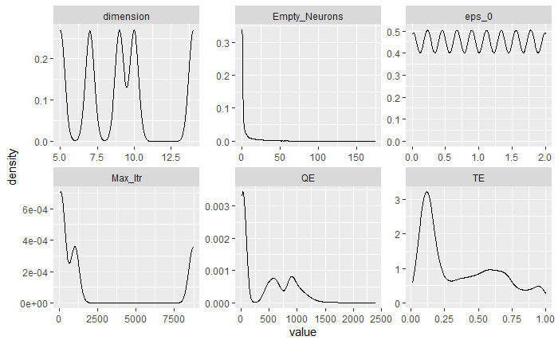

```r
model_df_FS1_T0_QE  %>%
  keep(is.numeric) %>%                     # Keep only numeric columns
  gather() %>%                             # Convert to key-value pairs
  ggplot(aes(value)) +                     # Plot the values
  facet_wrap(~ key, scales = "free") +   # In separate panels
  geom_density()
```

# Result of Hyper Parameter tuning

Captured “Quantization error” and " Topographic error" for all the combinations of hyper parameter. Total 14400 combinations were used for SOM Brero model training optimization. Initially without parallization, SOM Brero model training took 20 hrs for all the hyper parameter combinations. Below is the density graph for QE across all the combinations for FS1_data_T0.

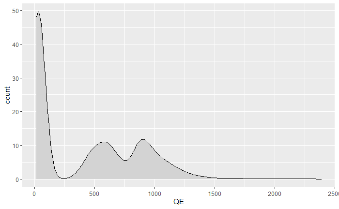

```r
gg_QE <- ggplot(model_df_FS1_T0_QE, aes(x = QE))
gg_QE + geom_density(aes(y = ..count..), fill = "lightgray") +
  geom_vline(aes(xintercept = mean(QE),),
             linetype = "dashed", size = 0.6,
             color = "#FC4E07")
```

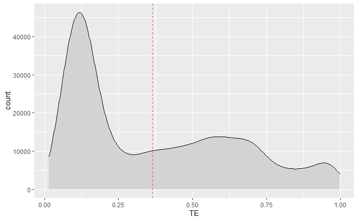

```r
gg_TE <- ggplot(model_df_FS1_T0_QE, aes(x = TE))
gg_TE + geom_density(aes(y = ..count..), fill = "lightgray") +
  geom_vline(aes(xintercept = mean(TE),),
             linetype = "dashed", size = 0.6,
             color = "#FC4E07")
```

```r
#ggarrange(gg_QE, gg_TE,
        #  labels = c("A", "B", "C"),
        #  ncol = 2, nrow = 2)
```

```r
summary(model_df_FS1_T0_QE$QE)
```

[output not shown]

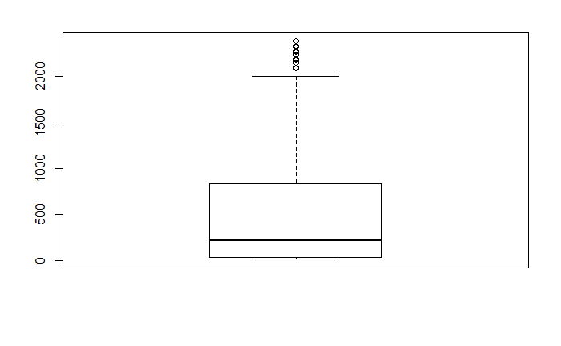

```r
boxplot(model_df_FS1_T0_QE$QE)
```

```r
# select results of hyper parameter optimization without TE
model_df_FS1_T0_QE <- model_df_FS1_T0_QE[model_df_FS1_T0_QE$QE<100, ]
model_df_FS1_T0_QE <- model_df_FS1_T0_QE[,-6]
model_df_FS1_T0_QE <- model_df_FS1_T0_QE[,-8]
```

```r
nrow(model_df_FS1_T0_QE)
```

```
[1] 7198
```

# Partial dependence

Need for pdp : Quantifying predictor importance.

Partial dependence plots are used for displying marginal dependency of predictors on the target variable. Different packages can be used for analysing partial dependency such as pdp, iceplots. Even some learning models like random forest and gradient booting regressor have built in method to highlight the partial dependencies. PDPs visualizes the relationship between a subset of the features (max 3) and the target variable while considering the average effect of the other predictors in the model.

# Analysis of impact of hyper parameters on QE

In my thesis, PDPs will help to interpret the marginal dependency of different hyper parameters on either “Quantization Error” or “Topographic Error” ( i.e. QE or TE namely).

Results were grouped by Dimension and then partial dependence plot concept was used

```r
#df_partial_plot_QE_FS1<- df_partial_plot_QE_FS1 %>%  select(1:7)

head(model_df_FS1_T0_QE)
```

|  | dimension | neigh_function | distance_func | init_proto | eps_0 | QE | scaling | Max_Itr |
| --- | --- | --- | --- | --- | --- | --- | --- | --- |
| 1 | 5 | gaussian | euclidean | random | 0.01 | 67.52452 | unitvar | 50 |
| 2 | 7 | gaussian | euclidean | random | 0.01 | 75.32251 | unitvar | 50 |
| 3 | 9 | gaussian | euclidean | random | 0.01 | 69.78615 | unitvar | 50 |
| 4 | 10 | gaussian | euclidean | random | 0.01 | 75.38731 | unitvar | 50 |
| 5 | 14 | gaussian | euclidean | random | 0.01 | 67.62518 | unitvar | 50 |
| 6 | 5 | letremy | letremy | random | 0.01 | 81.58464 | unitvar | 50 |

```r
# Group by Dimension and QE
df_partial_plot_QE_FS1_Avg<-aggregate(x = model_df_FS1_T0_QE$QE,                # Specify data column
          by = list(model_df_FS1_T0_QE$dimension),              # Specify group indicator
         FUN = mean)
colnames(df_partial_plot_QE_FS1_Avg) <- c("dimension","Avg_QE")
```

```r
head(df_partial_plot_QE_FS1_Avg)
```

|  | dimension | Avg_QE |
| --- | --- | --- |
| 1 | 5 | 33.73826 |
| 2 | 7 | 32.50107 |
| 3 | 9 | 31.56139 |
| 4 | 10 | 31.30843 |
| 5 | 14 | 29.98976 |

# Partial Dependence : using random forest’s built in method

To understand the partial dependence of the hyper parameters, random forest and pdp package was used.

Reason to choose random forest : as there are multiple predictors which contribute in prediction of QE.

```r
dim_avg_hyperParam.rf <- randomForest(Avg_QE ~ ., data = df_partial_plot_QE_FS1_Avg)
```

```r
library(randomForest)
#install.packages("pdp")
#library(pdp)

dim_avg_hyperParam.rf <- randomForest(Avg_QE ~ ., data = df_partial_plot_QE_FS1_Avg)
```

```
The response has five or fewer unique values.  Are you sure you want to do regression?
```

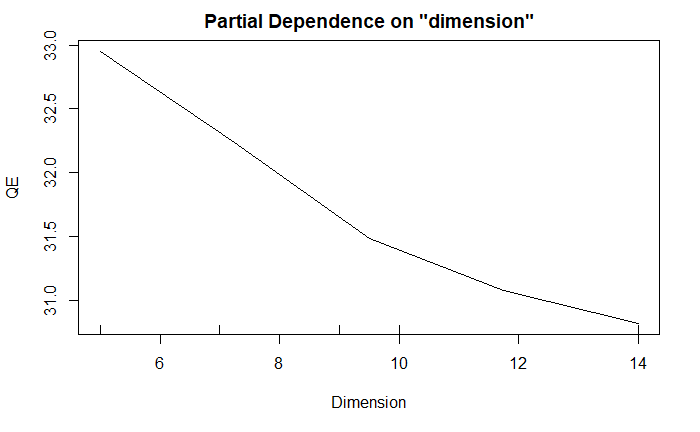

```r
partialPlot(dim_avg_hyperParam.rf, pred.data = df_partial_plot_QE_FS1_Avg, x.var = "dimension",ylab = "QE", xlab = "Dimension", theme(title = "Using randomForest's partialPlot function"))
```

# Partial Dependence : Using PDP package

Conclusion: as dimension increases QE decreases.

```r
head(partial(dim_avg_hyperParam.rf, pred.var = "dimension"))  # returns a data frame
```

|  | dimension | yhat |
| --- | --- | --- |
| 1 | 5 | 32.95246 |
| 2 | 7 | 32.77338 |
| 3 | 9 | 31.48530 |
| 4 | 11 | 31.25672 |
| 5 | 14 | 30.81829 |

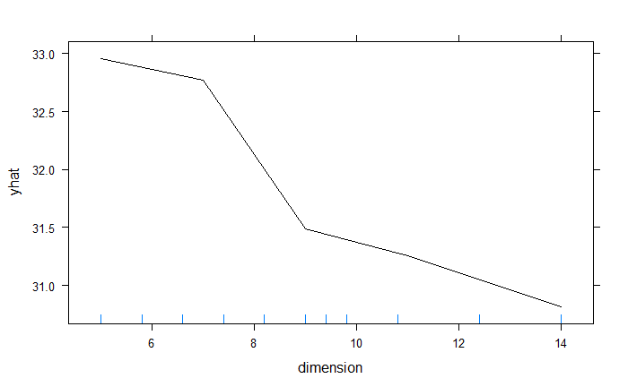

```r
partial(dim_avg_hyperParam.rf, pred.var = "dimension", plot = TRUE, rug = TRUE)
```

```r
NA
```

## Without aggregating the results of hyper parameter optimization

- PDP’s partial function helps to analyse impact of multiple predictors on target.
- Max of 3 predictors can be used for checking partial dependence
- Below entire FS1 hyper parameter optimization results were analysed where QE was less than 100.

Conclusion : with increase in dimension QE decreases. Additionally letremy neighborhood function showed lower QE through out the optimization process as compared to gaussian.

# Object to work with partial dependence

- To check the partial dependence random forest object created

```r
pdp_QE_hyperParam.rf <- randomForest(QE ~ ., data = model_df_FS1_T0_QE)
```

1. PartialPlot () of random forest
- can be used only for single predictors
- Plot one with respect to dimension shows decrease in the QE as the size increases

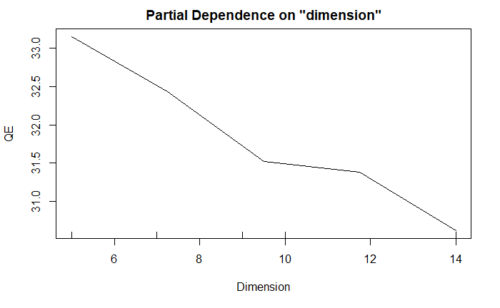

```r
partialPlot(pdp_QE_hyperParam.rf, pred.data = model_df_FS1_T0_QE, x.var = "dimension",ylab = "QE", xlab = "Dimension", theme(title = "Using randomForest's partialPlot function"))
```

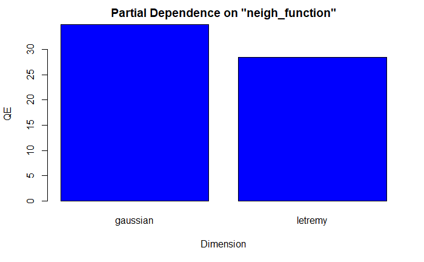

```r
partialPlot(pdp_QE_hyperParam.rf, pred.data = model_df_FS1_T0_QE, x.var = "neigh_function",ylab = "QE", xlab = "Dimension", theme(title = "Using randomForest's partialPlot function"))
```

```r
NA
NA
```

2. Partial() of pdp
- since we have multiple predictors its best to use PDP package
- Check effect of single predictor : dimension on the QE

```r
head(partial(pdp_QE_hyperParam.rf, pred.var = c("dimension")))
```

|  | dimension | yhat |
| --- | --- | --- |
| 1 | 5 | 33.14978 |
| 2 | 7 | 32.44003 |
| 3 | 9 | 31.48610 |
| 4 | 11 | 31.36769 |
| 5 | 14 | 30.65039 |

```r
p1<-partial(pdp_QE_hyperParam.rf, pred.var = c("dimension"), grid.resolution = 30,
        plot = TRUE, chull = TRUE,ylab = "QE", plot.engine = "ggplot2" , palette = "inferno")


p2<-partial(pdp_QE_hyperParam.rf, pred.var = "neigh_function",ylab = "QE", plot = TRUE, rug = TRUE,  plot.engine = "ggplot2" , palette = "inferno")

p3 <-partial(pdp_QE_hyperParam.rf, pred.var = c("dimension","neigh_function"), grid.resolution = 30,
        plot = TRUE, chull = TRUE,ylab = "QE", plot.engine = "ggplot2" , palette = "inferno")

#p4 <-partial(pdp_QE_hyperParam.rf, pred.var = c("dimension","neigh_function","init_proto"), grid.resolution = 40,
      #  plot = TRUE, chull = TRUE,ylab = "QE")
#"neigh_function","init_proto"

grid.arrange(p1, p2,p3, ncol = 2)
```

[output not shown]

3. plotPartial()
- used to plot object of Partial
- easy to handle asthetics along with highlighting partial dependece

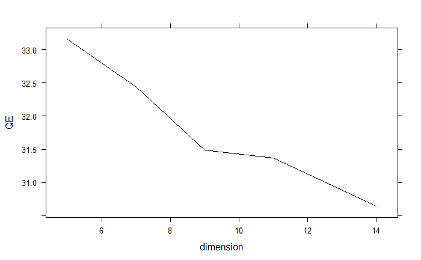

```r
library(ggplot2)
#autoplot(pd, contour = TRUE, legend.title = "Partial\ndependence")
#pd <- partial(pdp_QE_hyperParam.rf, pred.var = c("dimension", "neigh_function","init_proto"))
pd <- partial(pdp_QE_hyperParam.rf, pred.var = c("dimension"))

# Default PDP
pdp1 <- plotPartial(pd,ylab="QE")

pdp1
```

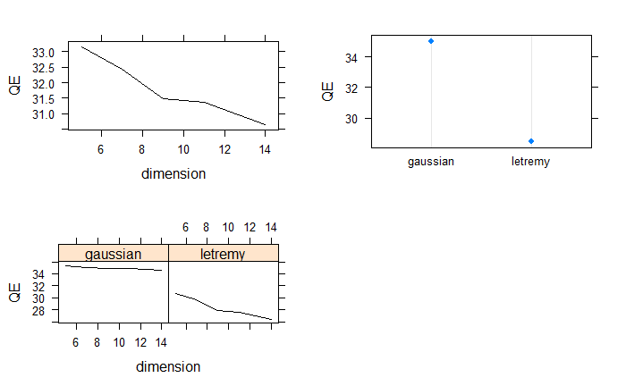

```r
p11<-partial(pdp_QE_hyperParam.rf, pred.var = c("dimension"))


p12<-partial(pdp_QE_hyperParam.rf, pred.var = "neigh_function")

p13 <-partial(pdp_QE_hyperParam.rf, pred.var = c("dimension","neigh_function"))

pdp_11<- plotPartial(p11,ylab="QE",)
pdp_12<- plotPartial(p12,ylab="QE")
pdp_13<- plotPartial(p13,ylab="QE")

grid.arrange(pdp_11, pdp_12,pdp_13, ncol = 2)
```

```r
NA
NA
```

```r
head(partial(pdp_QE_hyperParam.rf, pred.var = c("dimension") , grid.resolution = 40))
```

[output not shown]

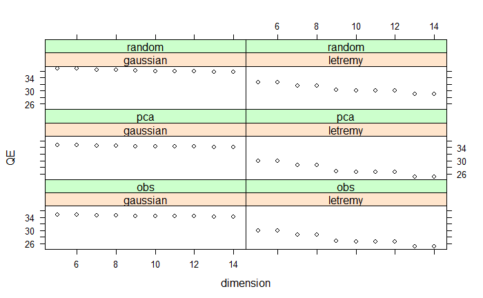

```r
p14 <-partial(pdp_QE_hyperParam.rf, pred.var = c("dimension","neigh_function","init_proto") , grid.resolution = 40)
p15 <-partial(pdp_QE_hyperParam.rf, pred.var = c("scaling","neigh_function","init_proto"), grid.resolution = 40)
p16 <-partial(pdp_QE_hyperParam.rf, pred.var = c("Max_Itr","neigh_function","init_proto"), grid.resolution = 40)
p17 <-partial(pdp_QE_hyperParam.rf, pred.var = c("eps_0","init_proto","neigh_function"), grid.resolution = 40)
p18 <-partial(pdp_QE_hyperParam.rf, pred.var = c("distance_func","init_proto","neigh_function"), grid.resolution = 40)


pdp_14<- plotPartial(p14,ylab="QE")
pdp_15<- plotPartial(p15,ylab="QE")
pdp_16<- plotPartial(p16,ylab="QE")
pdp_17<- plotPartial(p17,ylab="QE")
pdp_18<- plotPartial(p18,ylab="QE")

pdp_14
```

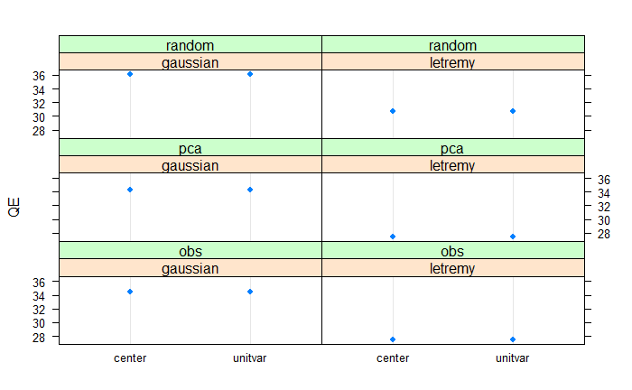

```r
pdp_15
```

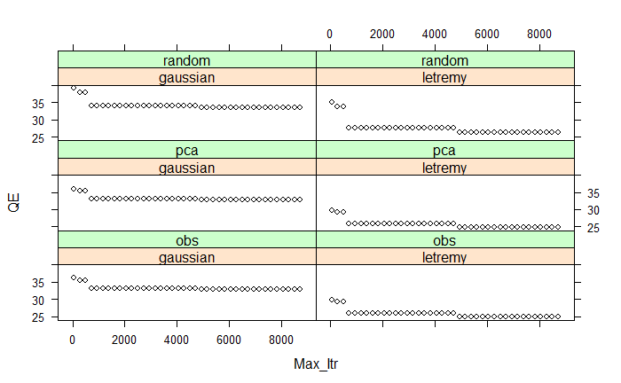

```r
pdp_16
```

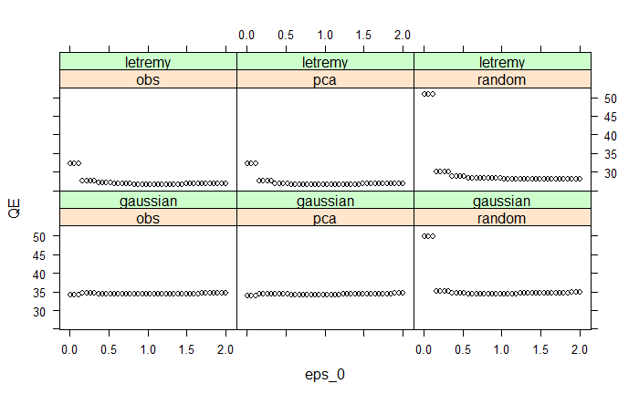

```r
pdp_17
```

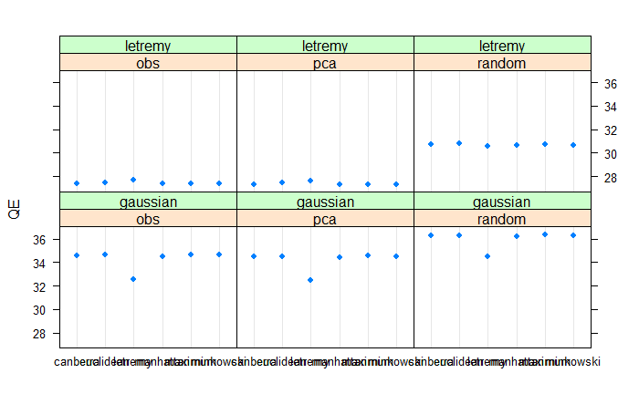

```r
pdp_18
```

# Check eps_0

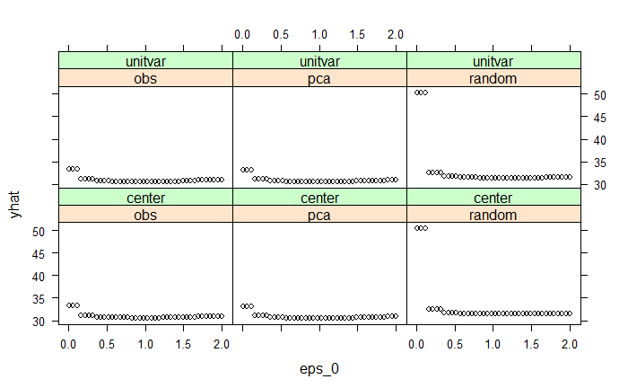

```r
partial(pdp_QE_hyperParam.rf, pred.var = c("eps_0","init_proto","scaling"), grid.resolution = 40, plot = TRUE)
```

# Quantization Error

- The QE is the average distance between each data vector and the BMU.
- The quantization error calculates the mean squared euclidean distance between the sample vectors and their respective cluster prototypes.
- which helps quantify the quality of the clustering
- declines as the map becomes larger.
- Larger map sizes result in more detailed patterns; smaller map sizes result in more general patterns.
- Quantization Error can not be used to com-pare maps of diffe rent sizes. [Show pdp for one dimension]

# Conclusion on QE (TE was not considered during this analysis)

- QE was significantly low with below features dimension: higher dimension..14 Radius type : Letremy Init proto : pca and obs Max itr: more than 4000 Scaling : both center and unitvar had similar effect as per our data eps_0 : shows similar result for all the values more than 0.3

# PDP for Dimension , neighbourhood function and prototye initialization

Reference : SOM Brero.pdf In pca the prototypes are initialized to the observations closest to a grid along the two first principal components of the data (numeric case) .

Conclusion : neighborhood funcion letremy and prototype initialization either obs or pca yeild lowest Quantization error

```r
p4<-partial(pdp_QE_hyperParam.rf, pred.var = c("dimension", "init_proto","scaling"), plot = TRUE, chull = TRUE)
p4

grid.arrange(p1, p2, p3,p4,p5,p5, ncol = 3,top="Partial Dependence on Quantization Error",
               left="Quantization Error")
```

[output not shown]

# Focusing on only one dimension

```r
names(dim5_df)
```

```
[1] "dimension"      "neigh_function" "distance_func"  "init_proto"     "eps_0"          "QE"             "scaling"
[8] "Max_Itr"
```

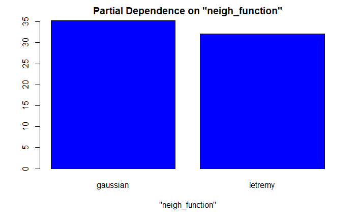

```r
partialPlot(dim5_rf_model, pred.data = dim5_df, x.var = "neigh_function")
```

```r
head(partial(dim5_rf_model, pred.var = c("neigh_function")))
```

|  | neigh_function | yhat |
| --- | --- | --- |
| 1 | gaussian | 35.2896 |
| 2 | letremy | 32.0846 |

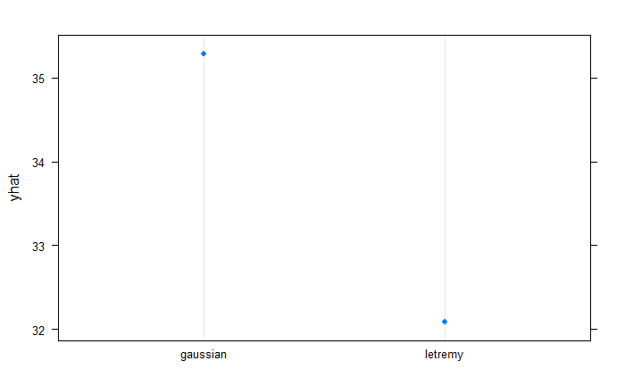

```r
partial(dim5_rf_model, pred.var = c( "neigh_function"),
        plot = TRUE, chull = TRUE)
```

```r
head(partial(dim5_rf_model, pred.var = c("init_proto", "neigh_function")))
```

|  | init_proto | neigh_function | yhat |
| --- | --- | --- | --- |
| 1 | obs | gaussian | 34.81869 |
| 2 | pca | gaussian | 34.72105 |
| 3 | random | gaussian | 36.37529 |
| 4 | obs | letremy | 31.41635 |
| 5 | pca | letremy | 31.38726 |
| 6 | random | letremy | 33.49744 |

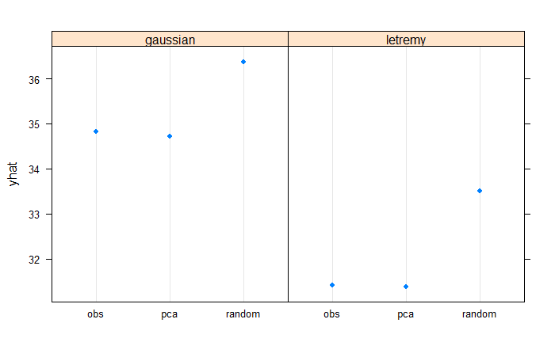

```r
partial(dim5_rf_model, pred.var = c( "init_proto","neigh_function"),
        plot = TRUE, chull = TRUE)
```

```r
head(partial(dim5_rf_model, pred.var = c( "Max_Itr","init_proto", "neigh_function")))
```

|  | Max_Itr | init_proto | neigh_function | yhat |
| --- | --- | --- | --- | --- |
| 1 | 50 | obs | gaussian | 36.41154 |
| 2 | 2938 | obs | gaussian | 33.55743 |
| 3 | 5826 | obs | gaussian | 33.40985 |
| 4 | 8715 | obs | gaussian | 33.40985 |
| 5 | 50 | pca | gaussian | 36.25059 |
| 6 | 2938 | pca | gaussian | 33.52453 |

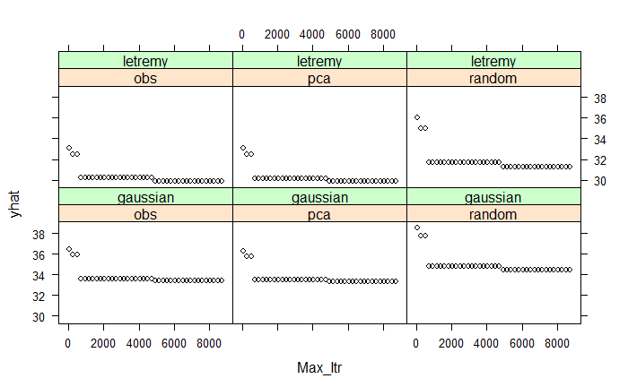

```r
partial(dim5_rf_model, pred.var = c( "Max_Itr","init_proto", "neigh_function"), grid.resolution = 40,
        plot = TRUE, chull = TRUE)
```

## Analysis of Topographic Error

```r
#Try different models


model_df_FS1_T0_TE <-read.csv("D:\\Fs1_hypertuningTotal14400.csv")
model_df_FS1_T0_TE <- model_df_FS1_T0_TE[model_df_FS1_T0_TE$QE<100, ]
model_df_FS1_T0_TE <- model_df_FS1_T0_TE[,-7]
model_df_FS1_T0_TE <- model_df_FS1_T0_TE[,-8]
head(model_df_FS1_T0_TE)
```

|  | dimension | neigh_function | distance_func | init_proto | eps_0 | TE | scaling | Max_Itr |
| --- | --- | --- | --- | --- | --- | --- | --- | --- |
| 1 | 5 | gaussian | euclidean | random | 0.01 | 0.8961561 | unitvar | 50 |
| 2 | 7 | gaussian | euclidean | random | 0.01 | 0.9127940 | unitvar | 50 |
| 3 | 9 | gaussian | euclidean | random | 0.01 | 0.9541021 | unitvar | 50 |
| 4 | 10 | gaussian | euclidean | random | 0.01 | 0.9248422 | unitvar | 50 |
| 5 | 14 | gaussian | euclidean | random | 0.01 | 0.9954102 | unitvar | 50 |
| 6 | 5 | letremy | letremy | random | 0.01 | 0.8542742 | unitvar | 50 |

```r
NA
NA
```

# Check the TE range

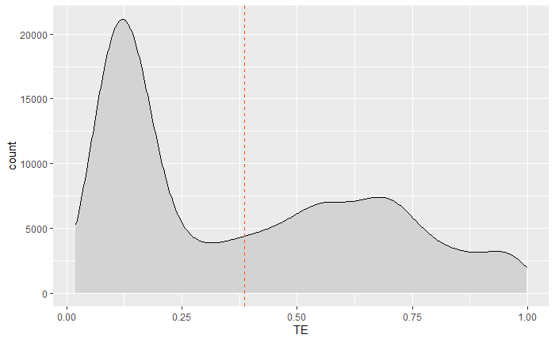

```r
#val_data_frame_FS1
g_FS1_T0_TE <- ggplot(model_df_FS1_T0_TE, aes(x = TE))


g_FS1_T0_TE + geom_density(aes(y = ..count..), fill = "lightgray") +
  geom_vline(aes(xintercept = mean(TE),),
             linetype = "dashed", size = 0.6,
             color = "#FC4E07")
```

# TE closer to 0 is good

# Partial dependence check for Topographic Error

Using random forests partialPlot method

```r
rf_model_TE <- randomForest(TE ~ ., data = model_df_FS1_T0_TE,importance=TRUE ,proximity=TRUE, oob.prox=TRUE)

#partialPlot(rf_model_TE, pred.data = model_df_FS1_T0_TE, x.var = "Max_Itr")
```

# Multiple predictors

[figure not shown]

```r
library(ggplot2)
#autoplot(pd, contour = TRUE, legend.title = "Partial\ndependence")
#pd <- partial(pdp_QE_hyperParam.rf, pred.var = c("dimension", "neigh_function","init_proto"))
pd_TE <- partial(rf_model_TE, pred.var = c("dimension"))

# Default PDP
pdp1_TE <- plotPartial(pd_TE,ylab="QE")

pdp1_TE
```

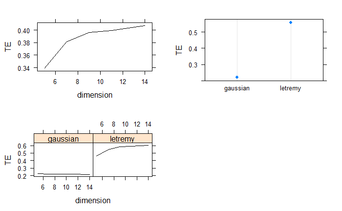

```r
p11_TE<-partial(rf_model_TE, pred.var = c("dimension"))


p12_TE<-partial(rf_model_TE, pred.var = "neigh_function")

p13_TE <-partial(rf_model_TE, pred.var = c("dimension","neigh_function"))

pdp_11_TE<- plotPartial(p11_TE,ylab="TE",)
pdp_12_TE<- plotPartial(p12_TE,ylab="TE")
pdp_13_TE<- plotPartial(p13_TE,ylab="TE")

grid.arrange(pdp_11_TE, pdp_12_TE,pdp_13_TE, ncol = 2)
```